# Analyzing Perceptual Errors and Individual Accuracy

Sima Najafzadehkhoei

2026-02-26

```r
library(imaginarycss)
```

# Perceptual Error Analysis

When people report how they see a social network, their perceptions systematically deviate from the true structure. The `imaginarycss` package classifies these deviations using two complementary tools:

- **`count_recip_errors()`** – counts reciprocity-related misperceptions.
- **`count_imaginary_census()`** – performs the full 10-category imaginary census introduced in Tanaka & Vega Yon (2023).

## Setup: A Small Example Network

We use a four-node network with one perceiver to illustrate the key ideas.

```r
# Build a true network and one perceiver's view
source_ <- c(1, 2, 3, 1, c(1, 2, 3) + 4)
target_ <- c(2, 1, 4, 4, c(2, 1, 4) + 4)

adjmat <- matrix(0L, nrow = 8, ncol = 8)
adjmat[cbind(source_, target_)] <- 1L
graph <- new_barry_graph(adjmat, n = 4)
```

Printing the graph shows some information:

```r
print(graph)
```

```
A barry_graph with 2 networks of size 4
.    .  1.00     .  1.00
 1.00     .     .     .
    .     .     .  1.00
    .     .     .     .
Skipping 4 rows. Skipping 4 columns.
```

## Reciprocity Errors

Reciprocity errors capture how often a perceiver incorrectly sees a directed tie as mutual (or vice versa). Higher counts indicate a stronger tendency to assume reciprocity where none exists.

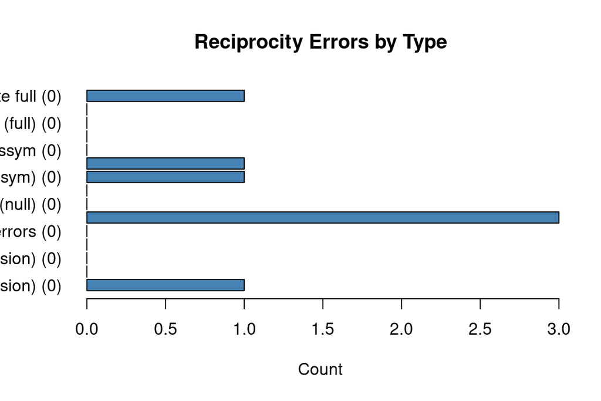

```r
recip_errors <- count_recip_errors(graph)
barplot(
  recip_errors$value,
  names.arg = recip_errors$name,
  horiz = TRUE, las = 1,
  col = "steelblue",
  xlab = "Count",
  main = "Reciprocity Errors by Type"
)
```

## Imaginary Census

The imaginary census classifies every perceiver–dyad combination into one of ten categories that capture the full spectrum from accurate perception to complete misperception (see `?count_imaginary_census` for definitions).

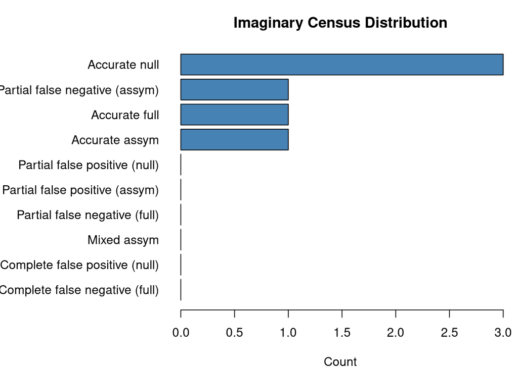

```r
census <- count_imaginary_census(graph)

# Aggregate by motif type using the summary method
agg <- summary(census)
agg <- sort(agg)

par(mar = c(4, 12, 3, 1))
barplot(
  agg,
  horiz = TRUE, las = 1,
  col = "steelblue",
  xlab = "Count",
  main = "Imaginary Census Distribution"
)
```

# Individual Accuracy

The function `tie_level_accuracy()` decomposes each perceiver’s accuracy into four probabilities:

| Measure | Description |
| --- | --- |
| `p_0_ego` | P(perceive no tie \| no tie exists) for ego dyads |
| `p_1_ego` | P(perceive tie \| tie exists) for ego dyads |
| `p_0_alter` | P(perceive no tie \| no tie exists) for alter dyads |
| `p_1_alter` | P(perceive tie \| tie exists) for alter dyads |

These rates are then used by `sample_css_network()` to generate null distributions for hypothesis testing.

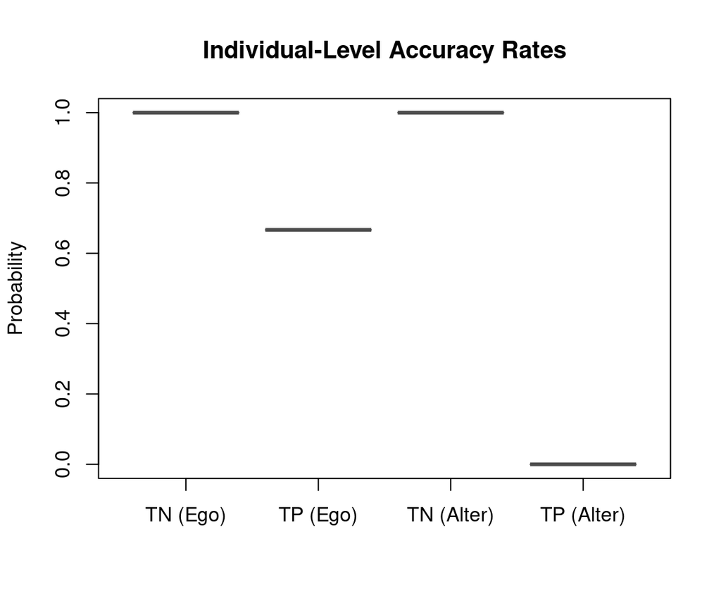

```r
accuracy <- tie_level_accuracy(graph)
acc_mat <- as.matrix(accuracy[, c("p_0_ego", "p_1_ego", "p_0_alter", "p_1_alter")])

boxplot(
  acc_mat,
  names = c("TN (Ego)", "TP (Ego)", "TN (Alter)", "TP (Alter)"),
  ylab = "Probability",
  main = "Individual-Level Accuracy Rates",
  col = c("#3498db", "#2980b9", "#e74c3c", "#c0392b"),
  border = "gray30"
)
```

# Null Model Testing

Using the individual accuracy rates, `sample_css_network()` generates synthetic CSS data that preserves each perceiver’s overall error rates but randomises which dyads are misperceived. Repeating this many times yields a null distribution for any network statistic.

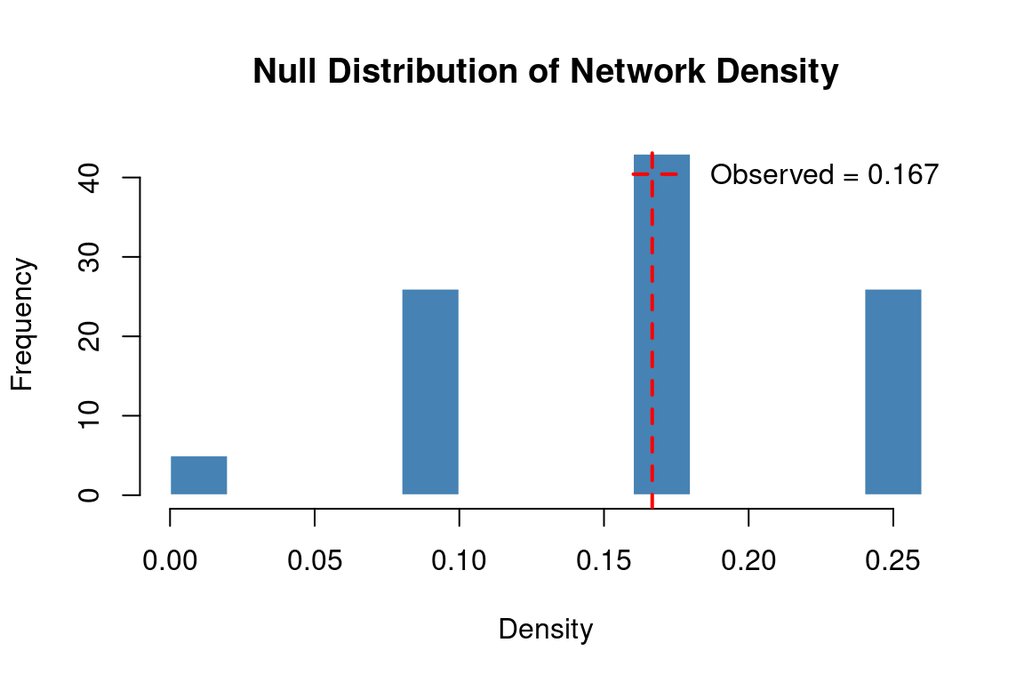

```r
set.seed(123)
n_samples <- 100

null_densities <- replicate(n_samples, {
  nets <- sample_css_network(graph, keep_baseline = FALSE)
  sum(nets[[1]]) / (4 * 3)
})

sampled <- sample_css_network(graph, keep_baseline = TRUE)
observed_density <- sum(sampled[[2]]) / (4 * 3)

hist(
  null_densities,
  breaks = 15,
  col = "steelblue",
  border = "white",
  main = "Null Distribution of Network Density",
  xlab = "Density"
)
abline(v = observed_density, col = "red", lwd = 2, lty = 2)
legend("topright",
  legend = paste("Observed =", round(observed_density, 3)),
  col = "red", lty = 2, lwd = 2, bty = "n"
)
```

## Key Takeaways

- **Reciprocity errors** quantify how people misperceive mutual relationships.
- The **imaginary census** provides a fine-grained, 10-category taxonomy of perceptual errors.
- **Individual accuracy rates** separate ego-involved from alter-only dyads and true positives from true negatives.
- **Null models** based on these rates let us test whether observed motif counts are more extreme than expected by chance.